# توضیحات کد پانداس

## قسمت اول

در این قسمت ابتدا با استفاده از `pd.read_csv` فایل های csv را خوانده.  
سپس با استفاده از `DataFrame.info()` و `DataFrame.describe()` اطلاعات کلی از دیتافریم ها بدست می اوریم.

## قسمت دوم

در این قسمت با ترکیب کردن چند دیتافریم، به دیتافریم مناسبی دست میابیم که به کمک ان میتوانیم به همه اطلاعات مورد نیاز دسترسی داشته باشیم.

```python
merged = pd.merge(players[['id_player', 'id_team']], goals[["id_player", "goals"]])
merged1 = pd.merge(merged, goalkeeping[["id_player" ,"goals_conceded"]])
merged2 = pd.merge(merged1, teams[["team_id", "team"]], left_on="id_team", right_on="team_id")
```

در مرحله دیتافریم بدست امده را به کمک `DataFrame.groupby()` دسته بندی میکنیم.

```python
grouped = merged2.groupby('id_team')
```

با جمع محتواهای ستون های `goals` و `goals_conceded` از سطرهایی که متعلق به یک تیم هستند. گل های زده و گل های خورده هر تیم را میتوانیم محاسبه کنیم.

```python
chart = grouped[['goals', 'goals_conceded']].sum()
chart
```

```python
list1 = teams['team_id'].values
for i in list1:
    if i not in chart.index:
        not_valid = i
        row = teams[teams['team_id'] == i]
        not_valid_index = row['team'].index
        print("name of the club that its data hasn't registered: ", end="")
        print(row['team'].values[0])
        print(f'this is team_id: {i}')
```

[output not shown]

```python
# Sorting teams based on their goals datas
output = chart.sort_values(['goal_difference', 'goals'], ascending=[False, True])
output
```

### نمایش بصری

در این قسمت به نمایش بصری داده های دیتافریم نهایی پرداخته شده. نمایش حاوی سه نمودار "گل های زده" و "گل های خورده" و "تفاضل گل" است.

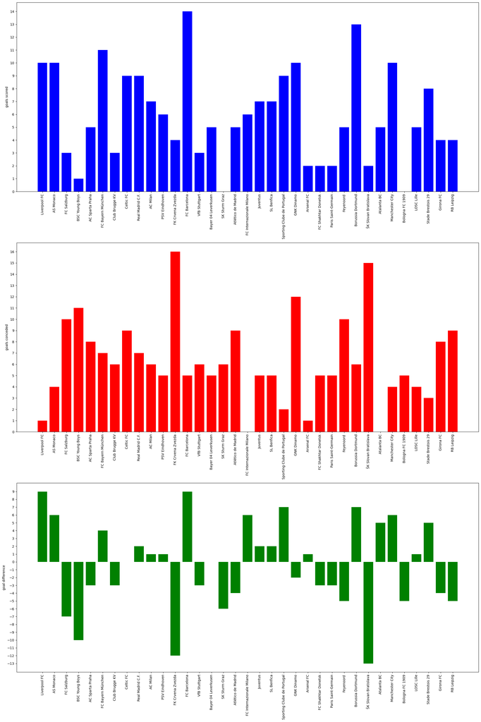

```python
# visualization
import matplotlib.pyplot as plt

team_name = update_teams['team'].values
goals_scored = chart['goals'].values
goals_conceded = chart['goals_conceded'].values
goal_difference = chart['goal_difference'].values

fig, ax = plt.subplots(3, 1, figsize=[20,30])
ax[0].bar(team_name, goals_scored, color='blue')
ax[0].tick_params(axis='x', labelrotation=90, labelcolor='black')
ax[0].set_yticks(np.arange(0, max(goals_scored)+1, 1))
ax[0].set_ylabel("goals scored")

ax[1].bar(team_name, goals_conceded, color='red')
ax[1].tick_params(axis='x', labelrotation=90, labelcolor='black')
ax[1].set_yticks(np.arange(0, max(goals_conceded)+1, 1))
ax[1].set_ylabel("goals conceded")

ax[2].bar(team_name, goal_difference, color='green')
ax[2].tick_params(axis='x', labelrotation=90, labelcolor='black')
ax[2].set_yticks(np.arange(min(goal_difference), max(goal_difference)+1, 1));
ax[2].set_ylabel("goal difference")
fig.tight_layout()
```

## قسمت سوم

در این قسمت از ما خواسته شده تا تمامی دیتافریم های موجود را با هم ترکیب کنیم. در تمامی دیتافریم های موجود به جز `teams` ستون `id_player` مشترک است. همچنین بین دیتافریم های `teams` و `players` نیز ستون `id_team` مشترک است.  
برای ترکیب دیتافریم ها و جلوگیری از استفاده حلقه، از تابع `reduce` از کتابخوانه `functools` استفاده شده است.

```python
from functools import reduce

merged3 = pd.merge(players, teams, left_on='id_team', right_on='team_id')
datas = [merged3, attacking, attempts, defending, disciplinary, distribution, goalkeeping, goals, key_stats]

merged4 = reduce(lambda left, right : pd.merge(left, right), datas)
merged4
```

در نهایت با استفاده از تابع `set_index()` طبق خواسته مسئله، دیتافریم ایندکس گذاری میشود.

```python
merged4.set_index(['team', 'player_name'])
```

## قسمت چهارم

در ابتدا دو دیتافریم `attempts` و `players` را برای دسترسی به اطلاعات مورد نظر ترکیب میکنیم.

```python
# merging dataframes to access players' data and attempts' data simultaneously
attempts1 = pd.merge(attempts, players)
attempts1
```

در مرحله بعد با ایجاد ستون جدید `accuracy`، دقت هر بازیکن در موقعیت های گل را تعیین میکنیم.

```python
attempts1['accuracy'] = attempts1['attempts_on_target'] / attempts1['total_attempts']
attempts1
```

در اینجا دیتافریم جدیدی از دیتافریم قبلی کپی میکنیم که ستون `accuracy` آن حاوی NaN نباشد.

```python
attempts2 = attempts1[attempts1['accuracy'].notna()]
attempts2
```

با استفاده از `quantile(x)` مقدار چارک ها را محاسبه میکنیم.

```python
q1 = attempts2['accuracy'].quantile(0.25)
q2 = attempts2['accuracy'].quantile(0.5)
q3 = attempts2['accuracy'].quantile(0.75)
```

## قسمت پنجم

### بخش اول

در بخش اول مجددا دیتافریم ها را به کمک `pd.read_csv` میخوانیم و با استفاده از `set_index()` ایندکس گذاری میکنیم و سپس با استفاده از `dropna` و متود `how='all'`، سطرهایی که تمام مقادیر آن NaN باشد را حذف میکند.

```python
attempts = pd.read_csv('./dataset/attempts_data.csv')
attempts = pd.DataFrame(attempts)
attempts.set_index('id_player', inplace=True)
attempts.dropna(how='all', inplace=True)
```

این کار را به ترتیب برای تمامی دیتافریم ها تکرار میکنیم.

### بخش دوم

ابتدا مجددا دیتافریم `players` را میخوانیم. سپس مقادیر یونیک ستون `position` را با استفاده از تابع `unique()`بدست میاوریم.

```python
players = pd.read_csv('./dataset/players_data.csv')
players = pd.DataFrame(players)
players['position'].unique()
# positions = players['position'].values
```

```
array(['STRIKER', nan, 'UNKNOWN', 'CENTRAL_MIDFIELDER', 'CENTRE_BACK',
       'ATTACKING_MIDFIELDER', 'FULL_BACK', 'WINGER', 'GOALKEEPER',
       'DEFENSIVE_MIDFIELDER'], dtype=object)
```

#### پیدا کردن دروازه بان ها

در این قسمت، ان دسته از NaN مقدارهایی که `field_postion` آن ها برابر "Goalkeeper" بوده است، مشخصا، مقدار `position` آن ها نیز باید "GOALKEEPER" باشد.

```python
nan_index_goalkeeper = players.iloc[nan_index][players['field_position'] == 'Goalkeeper'].index
```

```python
update_players = players.copy()
```

```python
update_players.iloc[nan_index_goalkeeper] = 'GOALKEEPER'
```

#### پیدا کردن مدافعین

در این قسمت پس از تست و بررسی چند فیچر، به این نتیجه رسیدم که ستون `crosses_attempted` رابطه نزدیک تری با تعیین مدافعان دارد. به این شکل که اگر مقدار ان از میانگین داده ها بیشتر باشد، احتمالا `position` ان متعلق به پست "FULL_BACK" خواهد بود و اگر کمتر از میانگین باشد احتمالا متعلق به پست "CENTRE_BACK" خواهد بود.  
آن دسته از NaN مقدارهایی که ستون `crosses_attempted` ان نیز NaN بوده است را برابر "UNKNOWN" قرار دادم.

مقدار میانگین که بر اساس ان نوع مدافع تعیین شده است:

```python
train_set = df.drop(nan_index_defender)
defender = train_set[train_set["field_position"] == 'Defender']
threshold = defender["crosses_attempted"].mean()
threshold
```

```
2.9844559585492227
```

```python
full_back = df.iloc[nan_index_defender][df["crosses_attempted"] >= threshold].index
df.loc[full_back, 'position'] = "FULL_BACK"
```

```python
centre_back = df.iloc[nan_index_defender][df['crosses_attempted'] < threshold].index
df.loc[centre_back, 'position'] = "CENTRE_BACK"
```

داده هایی که ستون `crosses_attempted` آن نیز برابر NaN بود را برابر "UNKNOWN" قرار میدهیم.

```python
unknown = df.loc[nan_index_defender][df['crosses_attempted'].isnull()].index
df.loc[unknown, 'position'] = "UNKNOWN"
```

در ادامه رابطه مناسبی برای تعیین پست هافبک ها و مهاجمین پیدا نکردم:(